# Анализ рынка видеоигр

## Портреты пользователей по регионам

### Самые популярные платформы и жанры

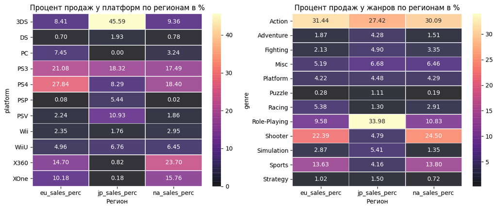

```python
#Создаю сводные таблицы для графиков
games_sales_ter = games_actual.pivot_table(index = 'platform', values = ['na_sales', 'eu_sales', 'jp_sales'], aggfunc =  'sum')
games_sales_gen = games_actual.pivot_table(index = 'genre', values = ['na_sales', 'eu_sales', 'jp_sales'], aggfunc =  'sum')

#Перевожу сумму в проценты
for name, value in games_sales_ter.iteritems():
    games_sales_ter[name+'_perc'] = round((games_sales_ter[name] /
                       games_sales_ter[name].sum()) * 100, 2)

for name, value in games_sales_gen.iteritems():
    games_sales_gen[name+'_perc'] = round((games_sales_gen[name] /
                       games_sales_gen[name].sum()) * 100, 2)

#Убираю столбцы которые не процентные
games_sales_ter = games_sales_ter.drop(['na_sales', 'eu_sales', 'jp_sales'], axis=1)
games_sales_gen = games_sales_gen.drop(['na_sales', 'eu_sales', 'jp_sales'], axis=1)

#Строю график 2 в 1
fig, ax = plt.subplots(1,2)

fig.set_figheight(5)
fig.set_figwidth (12)

sns.heatmap(games_sales_ter, annot=True, linewidths=.5, cmap='magma',fmt = '0.2f', alpha=.8, ax=ax[0])
sns.heatmap(games_sales_gen, annot=True, linewidths=.5, cmap='magma',fmt = '0.2f', alpha=.8, ax=ax[1])

ax[0].title.set_text("Процент продаж у платформ по регионам в %")
ax[1].title.set_text("Процент продаж у жанров по регионам в %")
ax[0].set_xlabel("Платформа")
ax[0].set_xlabel("Регион")
ax[1].set_xlabel("Жанр")
ax[1].set_xlabel("Регион")

fig.tight_layout()
plt.show();
```

Для пользователей из Европы.

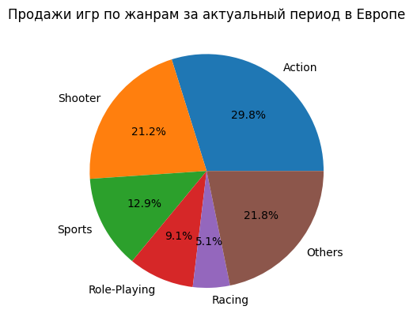

```python
top5_genres_eu = games_actual.pivot_table(index='genre', values ='eu_sales', aggfunc =  'sum').sort_values(by='eu_sales', ascending=False).reset_index()
others = top5_genres_eu.loc[4:]['eu_sales'].sum()
top5_genres_eu = top5_genres_eu.head(5)
top5_genres_eu.loc[5] = ['Others', others]

fig1, ax = plt.subplots()
ax.pie(top5_genres_eu['eu_sales'], labels=top5_genres_eu['genre'], autopct='%1.1f%%')
ax.set_title('Продажи игр по жанрам за актуальный период в Европе')
plt.show()
```

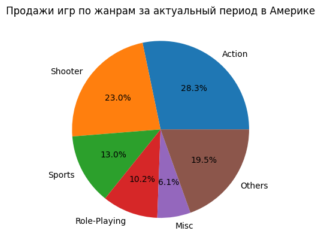

```python
top5_genres_na = games_actual.pivot_table(index='genre', values ='na_sales', aggfunc =  'sum').sort_values(by='na_sales', ascending=False).reset_index()
others = top5_genres_na.loc[4:]['na_sales'].sum()
top5_genres_na = top5_genres_na.head(5)
top5_genres_na.loc[5] = ['Others', others]

fig1, ax = plt.subplots()
ax.pie(top5_genres_na['na_sales'], labels=top5_genres_na['genre'], autopct='%1.1f%%')
ax.set_title('Продажи игр по жанрам за актуальный период в Америке')
plt.show()
```

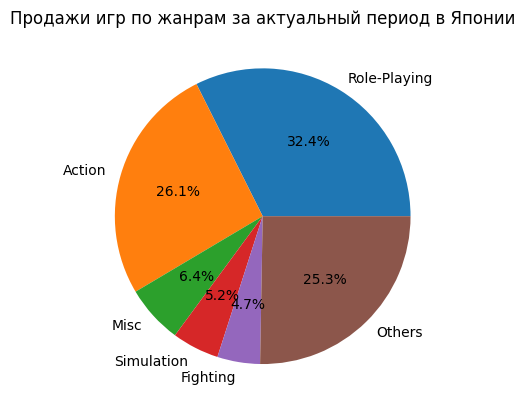

```python
top5_genres_jp = games_actual.pivot_table(index='genre', values ='jp_sales', aggfunc =  'sum').sort_values(by='jp_sales', ascending=False).reset_index()
others = top5_genres_jp.loc[4:]['jp_sales'].sum()
top5_genres_jp = top5_genres_jp.head(5)
top5_genres_jp.loc[5] = ['Others', others]

fig1, ax = plt.subplots()
ax.pie(top5_genres_jp['jp_sales'], labels=top5_genres_jp['genre'], autopct='%1.1f%%')
ax.set_title('Продажи игр по жанрам за актуальный период в Японии')
plt.show()
```

### Влияние рейтинга ESRB на продажи

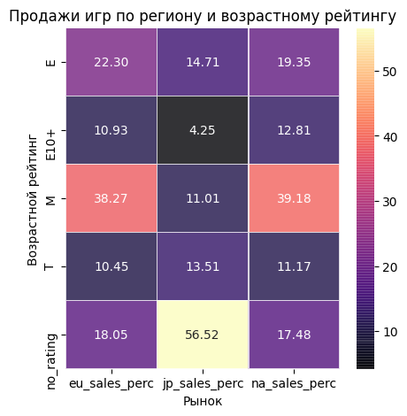

```python
games_sales_rtg = games_actual.pivot_table(index = 'rating', values = ['na_sales', 'eu_sales', 'jp_sales'], aggfunc =  'sum')

for name, value in games_sales_rtg.iteritems():
    games_sales_rtg[name+'_perc'] = round((games_sales_rtg[name] /
                       games_sales_rtg[name].sum()) * 100, 2)

games_sales_rtg = games_sales_rtg.drop(['na_sales', 'eu_sales', 'jp_sales'], axis=1)


plt.figure(figsize=(5, 5))

sns.heatmap(games_sales_rtg, annot=True, linewidths=.5, cmap='magma',fmt = '0.2f', alpha=.8)

plt.title('Продажи игр по региону и возрастному рейтингу')
plt.ylabel('Возрастной рейтинг')
plt.xlabel('Рынок')
plt.show();
```

В Европе и Северной Америке показатели схожи: популярнее всего игры 17+. В Японии есть свои рейтинговые агенства поэтому у ESRB большинство игр для этого региона не оценены (Вероятно оценки есть только у игр, которые выходили и в других регионах).

## Проверка Гипотез

Необходимо проверить две гипотезы:

- Средние пользовательские рейтинги платформ Xbox One и PC одинаковые.
- Средние пользовательские рейтинги жанров Action (англ. «действие», экшен-игры) и Sports (англ. «спортивные соревнования») разные.  
  Начну с первой  
  Для сравнения двух генеральных совокупностей я буду использовать метод scipy.stats.ttest_ind - именно он позволит проверить гипотезу об их равенстве среднего. Соответственно нулевые гипотезы у меня будут удтверждать что они равны. p-value выберу стандартный в 5%.

### Рейтинги XOne и PC

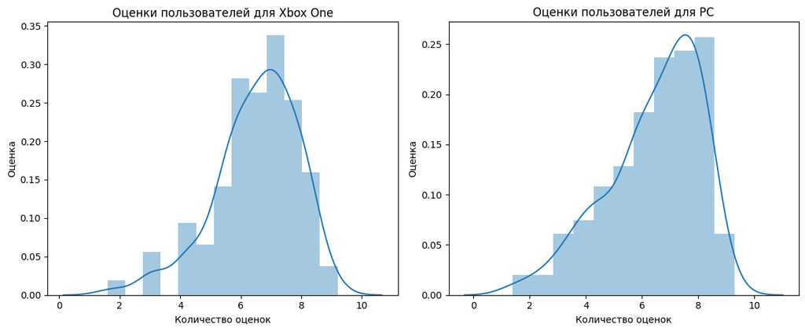

```python
XOne = games_actual.query('platform == "XOne"').reset_index(drop=True)['user_score'].dropna()
PC = games_actual.query('platform == "PC"').reset_index(drop=True)['user_score'].dropna()

fig, ax = plt.subplots(1,2)

fig.set_figheight(5)
fig.set_figwidth (12)

sns.distplot(XOne, ax=ax[0])
sns.distplot(PC, ax=ax[1])

ax[0].title.set_text("Оценки пользователей для Xbox One")
ax[1].title.set_text("Оценки пользователей для PC")
ax[0].set_xlabel("Количество оценок")
ax[1].set_xlabel("Количество оценок")
ax[0].set_ylabel("Оценка")
ax[1].set_ylabel("Оценка")
fig.tight_layout()
plt.show();
```

Судя по графикам, оценки ПК более высокие, лучше сгруппированны и их меньше, однако кривые распределения схожи. Чтобы это проверить, сформулирую гипотезу:  
H0: Средние пользовательские рейтинги платформ Xbox One и PC одинаковые  
Н1: Средние пользовательские рейтинги платформ Xbox One и PC разные  
Уровень значимости α = 0.05 Если Pvalue будет меньше этого уровня значимости, то нулевая гипотеза будет отвергнута

Для проверки буду использовать ttest_ind

```python
alpha = .05
results = st.ttest_ind(XOne, PC)
print('p-значение: ', results.pvalue)
if results.pvalue < alpha:
    print("Отвергаем нулевую гипотезу")
else:
    print("Не получилось отвергнуть нулевую гипотезу")
```

```
p-значение:  0.5535080500643661
Не получилось отвергнуть нулевую гипотезу
```

### Рейтинги Action и Sports

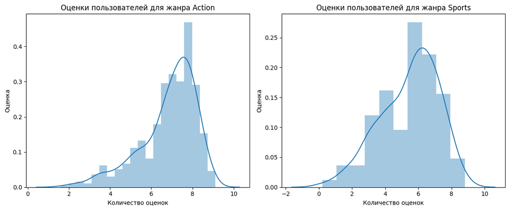

```python
Action_score = games_actual.query('genre == "Action"').reset_index(drop=True)['user_score'].dropna()
Sports_score = games_actual.query('genre == "Sports"').reset_index(drop=True)['user_score'].dropna()

fig, ax = plt.subplots(1,2)

fig.set_figheight(5)
fig.set_figwidth (12)

sns.distplot(Action_score, ax=ax[0])
sns.distplot(Sports_score, ax=ax[1])

ax[0].title.set_text("Оценки пользователей для жанра Action")
ax[1].title.set_text("Оценки пользователей для жанра Sports")
ax[0].set_xlabel("Количество оценок")
ax[1].set_xlabel("Количество оценок")
ax[0].set_ylabel("Оценка")
ax[1].set_ylabel("Оценка")
fig.tight_layout()
plt.show();
```

Графики не похожи. Среди спортивных игр большая доля с оценками 4 и 3. Кривые распределения разные. Сформулирую гипотезу:  
H0: Средние пользовательские рейтинги жанров Action и Sports одинаковые.  
Н1: Средние пользовательские рейтинги жанров Action и Sports разные.  
Уровень значимости α = 0.05 Если Pvalue будет меньше этого уровня значимости, то нулевая гипотеза будет отвергнута

```python
alpha = .05
results = st.ttest_ind(Action_score, Sports_score)
print('p-значение: ', results.pvalue)    # тест двухсторонний
if results.pvalue < alpha:
    print("Отвергаем нулевую гипотезу")
else:
    print("Не получилось отвергнуть нулевую гипотезу")
```

```
p-значение:  4.8045233804629176e-26
Отвергаем нулевую гипотезу
```

Присутствуют статистически значимые отличия, нулевая гипотеза отвергнута.

## Выводы

- PS4 и XOne являются самыми перспективными платформами для продаж в 2017 году и только набирают свой рост. Игры на 3DS, PSV и Wii U в следующем году тоже будут продаваться, но роста от них ожидать не стоит.
- Оценки критиков если и влияют на продажи, то незначительно, а оценки игроков не влияют вовсе
- Самые стабильно прибыльные жанры это Шутеры, Спортивные игры и платформеры, Суммарные продажи лучше всего у Экшена, Шутеров и Ролевых игр.
- В Америке хорошо продаются игры для PS4 и XOne, в Европе лучше сконцентрироваться на PS4, а в японии на 3DS и PSV.
- В Европе и Северной Америке хорошо продаются игры 17+
- Было проверенно две гипотезы, вот их результаты:
  - Нельзя удтверждать, что оценки пользователей для игр на хбох и пк отличаются.
  - Оценки пользователей для игр жанров Экшн и Спортивные игры различны.
- Рекламный бюджет лучше потратить на игры, наиболее соответствующие нижеуказанным критериям:
  - Это игра для платформ PS4 и/или Xbox One
  - В жанре Шутер или Спортивная игра
  - С возрастным рейтингом 17+
  - Лучше рекламировать такую игру в Европе или Сеерной Америке
  - Отзывы критиков не должны быть ниже средних

В начало